# SBM output analysis: CPTAC (BRCA) data

Anne-Claire Kroger, anne-claire.kroger@curie.fr

2024-06-28

# Read the SBM output and do some first visualization of the results

### Import published clustering information

```r
brca_cluster <- read.csv("data/input_brca_cptac/BRCA_meta_paper_clustering.csv")
rownames(brca_cluster) <- brca_cluster$Sample.ID
```

## Single-omics hSBM

### RNA 4k features

Loading all the results from hSBM using the custom function. Results will be saved in the right structure in the specifiied folder names if using the python script (see script 02).

- folder_path - Path to the folder with saved results as specifified in the python script 02
- level - level of the SBM output to be loaded
- type - name used to save the “worddist” matrices in python, as the SBM algorithm doesn’t do it in the save.data() function like the rest of the output
- omics_leyers - number of omics layers used in this analysis, default is 1

```r
#load data
brca_rna_4k_l0 <- read_sbm_output(folder_path = "data/sbm_output_brca_cptac/brca_rna_tests_4k", level = 0, type = "brca_rna_4k")
brca_rna_4k_l1 <- read_sbm_output(folder_path = "data/sbm_output_brca_cptac/brca_rna_tests_4k", 1, type = "brca_rna_4k")
brca_rna_4k_l2 <- read_sbm_output(folder_path = "data/sbm_output_brca_cptac/brca_rna_tests_4k", 2, type = "brca_rna_4k")
```

The output object contains all relevant outoput for one level:

```r
as.data.frame(brca_rna_4k_l0$summary)
```

```
##   n_clust n_topics max_topic_length average_topic_length n_samples n_features
## 1     119     1251               71             3.197442       119       4000
```

```r
as.data.frame(brca_rna_4k_l1$summary)
```

```
##   n_clust n_topics max_topic_length average_topic_length n_samples n_features
## 1       4       39              551             102.5641       119       4000
```

```r
as.data.frame(brca_rna_4k_l2$summary)
```

```
##   n_clust n_topics max_topic_length average_topic_length n_samples n_features
## 1       1        2             3793                 2000       119       4000
```

Check out the cluster numbers through the summary list in each sbm object. Level 1 has 4 clusters which matches the expected number of clusters for the cancer type.

We can visualize the results through a sankey plot for several levels or a barplot for one level. In both cases we directly compare the results to the previously published annotations

```r
#sankey plot l1 & l2

brca_samp <- as.list(brca_cluster$Sample.ID)

#using level 1 & 2 in this case
l1 <- unlist(lapply(brca_samp, function(samp) {which(brca_rna_4k_l1$clust == samp, arr.ind = TRUE)[2]}))
l2 <- unlist(lapply(brca_samp, function(samp) {which(brca_rna_4k_l2$clust == samp, arr.ind = TRUE)[2]}))

#add the prviously published annotation "NMF.Cluster"
df <- data.frame("level_2" = l2, "level_1" = l1, "brca_subgroup" = brca_cluster$NMF.Cluster, row.names = brca_cluster$Sample.ID)
df_s <- get_sankey_input(df)
p <- sankeyNetwork(Links = df_s$links, Nodes = df_s$nodes,
                     Source = "IDsource", Target = "IDtarget",
                     Value = "value", NodeID = "name",
                     sinksRight=FALSE)
```

```
## Links is a tbl_df. Converting to a plain data frame.
```

```r
p
```

[interactive chart not shown]

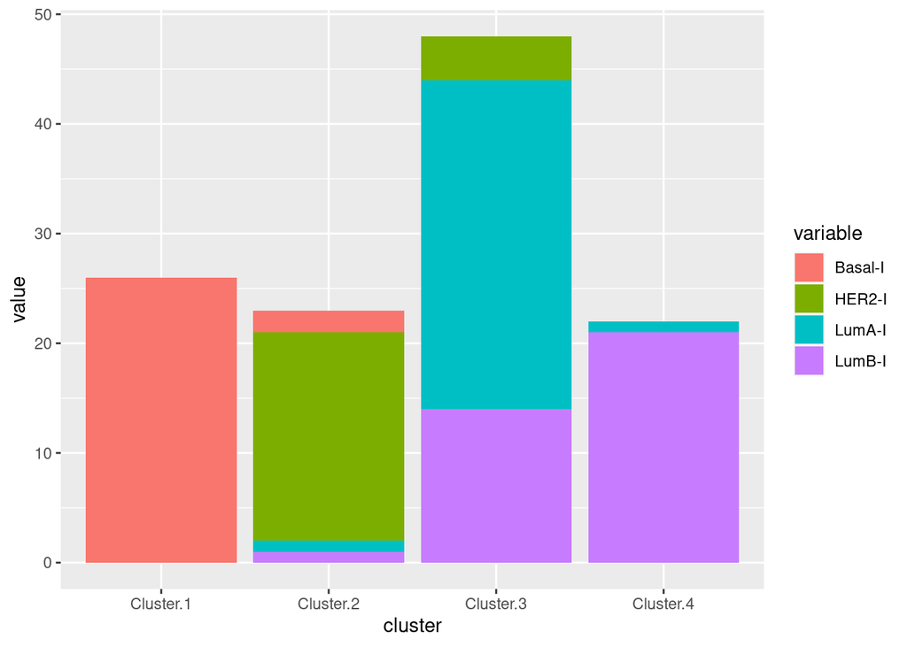

```r
#barplot level 1

df <- get_nsbmclust_df(brca_rna_4k_l1$clust, anno = brca_cluster, anno_samplecol = 1, anno_groupcol = 8)

df$cluster <- rownames(df)
df <- melt(df, id = "cluster")

ggplot(df, aes(fill=variable, y=value, x=cluster)) +
    geom_bar(position="stack", stat="identity")
```

### Prot 2k feature

```r
#load data
brca_prot_2k_l0 <- read_sbm_output(folder_path = "data/sbm_output_brca_cptac/brca_prot_tests_2k", 0, type = "brca_prot_2k")
brca_prot_2k_l1 <- read_sbm_output(folder_path = "data/sbm_output_brca_cptac/brca_prot_tests_2k", 1, type = "brca_prot_2k")
brca_prot_2k_l2 <- read_sbm_output(folder_path = "data/sbm_output_brca_cptac/brca_prot_tests_2k", 2, type = "brca_prot_2k")
```

```r
as.data.frame(brca_prot_2k_l0$summary)
```

```
##   n_clust n_topics max_topic_length average_topic_length n_samples n_features
## 1     119      665               65             3.007519       119       2000
```

```r
as.data.frame(brca_prot_2k_l1$summary)
```

```
##   n_clust n_topics max_topic_length average_topic_length n_samples n_features
## 1       5       66              382             30.30303       119       2000
```

```r
as.data.frame(brca_prot_2k_l2$summary)
```

```
##   n_clust n_topics max_topic_length average_topic_length n_samples n_features
## 1       1        4             1617                  500       119       2000
```

```r
#sankey plot l1 & l2

brca_samp <- as.list(brca_cluster$Sample.ID)

#using level 1 & 2 in this case
l1 <- unlist(lapply(brca_samp, function(samp) {which(brca_prot_2k_l1$clust == samp, arr.ind = TRUE)[2]}))
l2 <- unlist(lapply(brca_samp, function(samp) {which(brca_prot_2k_l2$clust == samp, arr.ind = TRUE)[2]}))

#add the prviously published annotation "NMF.Cluster"
df <- data.frame("level_2" = l2, "level_1" = l1, "brca_subgroup" = brca_cluster$NMF.Cluster, row.names = brca_cluster$Sample.ID)
df_s <- get_sankey_input(df)
p <- sankeyNetwork(Links = df_s$links, Nodes = df_s$nodes,
                     Source = "IDsource", Target = "IDtarget",
                     Value = "value", NodeID = "name",
                     sinksRight=FALSE)
```

```
## Links is a tbl_df. Converting to a plain data frame.
```

```r
p
```

[interactive chart not shown]

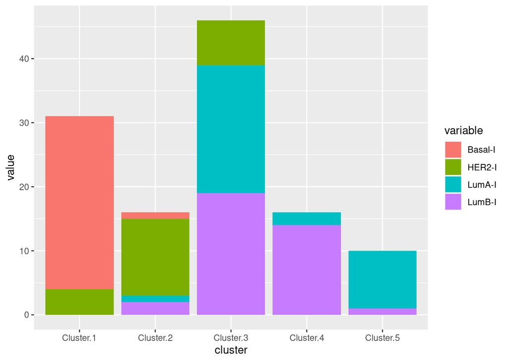

```r
#barplot level 1

df <- get_nsbmclust_df(brca_prot_2k_l1$clust, anno = brca_cluster, anno_samplecol = 1, anno_groupcol = 8)

df$cluster <- rownames(df)
df <- melt(df, id = "cluster")

ggplot(df, aes(fill=variable, y=value, x=cluster)) +
    geom_bar(position="stack", stat="identity")
```

### Phospho 8k features

```r
#load data
brca_phos_8k_l0 <- read_sbm_output(folder_path = "data/sbm_output_brca_cptac/brca_phos_tests_8k", 0, type = "brca_phos_8k")
brca_phos_8k_l1 <- read_sbm_output(folder_path = "data/sbm_output_brca_cptac/brca_phos_tests_8k", 1, type = "brca_phos_8k")
brca_phos_8k_l2 <- read_sbm_output(folder_path = "data/sbm_output_brca_cptac/brca_phos_tests_8k", 2, type = "brca_phos_8k")
brca_phos_8k_l3 <- read_sbm_output(folder_path = "data/sbm_output_brca_cptac/brca_phos_tests_8k", 3, type = "brca_phos_8k")
```

```r
as.data.frame(brca_phos_8k_l0$summary)
```

```
##   n_clust n_topics max_topic_length average_topic_length n_samples n_features
## 1     117     1060              907              7.59434       119       8050
```

```r
as.data.frame(brca_phos_8k_l1$summary)
```

```
##   n_clust n_topics max_topic_length average_topic_length n_samples n_features
## 1       3       37             1559             217.5676       119       8050
```

```r
as.data.frame(brca_phos_8k_l2$summary)
```

```
##   n_clust n_topics max_topic_length average_topic_length n_samples n_features
## 1       2        5             5465                 1610       119       8050
```

```r
as.data.frame(brca_phos_8k_l3$summary)
```

```
##   n_clust n_topics max_topic_length average_topic_length n_samples n_features
## 1       1        3             5465             2683.333       119       8050
```

```r
#sankey plot l1 & l2

brca_samp <- as.list(brca_cluster$Sample.ID)

#using level 1 & 2 in this case
l1 <- unlist(lapply(brca_samp, function(samp) {which(brca_phos_8k_l1$clust == samp, arr.ind = TRUE)[2]}))
l2 <- unlist(lapply(brca_samp, function(samp) {which(brca_phos_8k_l2$clust == samp, arr.ind = TRUE)[2]}))
l3 <- unlist(lapply(brca_samp, function(samp) {which(brca_phos_8k_l3$clust == samp, arr.ind = TRUE)[2]}))


#add the prviously published annotation "NMF.Cluster"
df <- data.frame("level_3" = l3, "level_2" = l2, "level_1" = l1, "brca_subgroup" = brca_cluster$NMF.Cluster, row.names = brca_cluster$Sample.ID)
df_s <- get_sankey_input(df)
p <- sankeyNetwork(Links = df_s$links, Nodes = df_s$nodes,
                     Source = "IDsource", Target = "IDtarget",
                     Value = "value", NodeID = "name",
                     sinksRight=FALSE)
```

```
## Links is a tbl_df. Converting to a plain data frame.
```

```r
p
```

[interactive chart not shown]

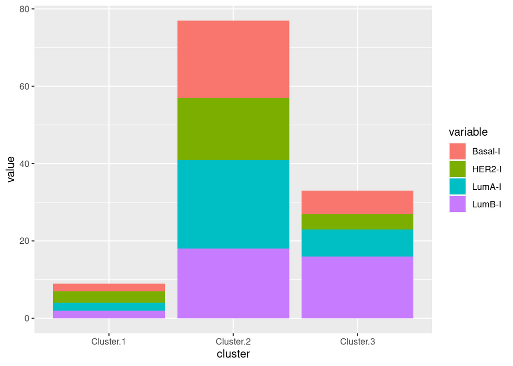

```r
#barplot level 1

df <- get_nsbmclust_df(brca_phos_8k_l1$clust, anno = brca_cluster, anno_samplecol = 1, anno_groupcol = 8)

df$cluster <- rownames(df)
df <- melt(df, id = "cluster")

ggplot(df, aes(fill=variable, y=value, x=cluster)) +
    geom_bar(position="stack", stat="identity")
```

### Further analysis for any omics analysis level of interest

(can also be copy and pasted under each analysis)

```r
#define omics type and matching level of interest
loi <- brca_rna_4k_l1

loi_name <- "hSBM l=1 brca rna 4k"
```

Calculate the rand index

```r
df <- get_nsbmclust_df(loi$clust, anno = brca_cluster, anno_samplecol = 1, anno_groupcol = 8)
rand_index_sbmcluster(df)
```

```
## [1] 0.827
```

Take a closer look at topics by using the analyse_topics function which calculates different normalisations for topic scores

```r
stats_loi <- analyse_topics(loi)
```

Check the centered topic values aka “importance” for each each topic using the SBM assigned clustering. Centered topic values per cluster are calculated according to this publication: https://www.mdpi.com/2072-6694/16/7/1350

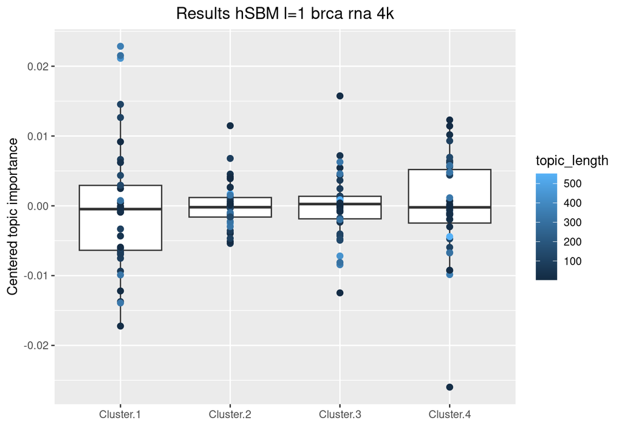

```r
ggplot(stats_loi$info_centered, aes(x=cluster, y=value))+
  geom_boxplot() +
  geom_point(aes(group = factor(cluster), color=topic_length), show.legend = T, size = 2) +
  labs(x="", y="Centered topic importance", title = paste("Results", loi_name)) +
  theme(plot.title = element_text(hjust = 0.5))
```

Check correlation between centered topic importance and topic length, vs correlation when only using mean topic importance without centering by cluster.

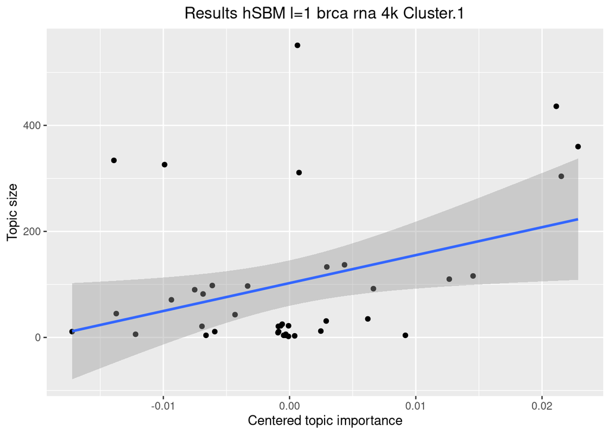

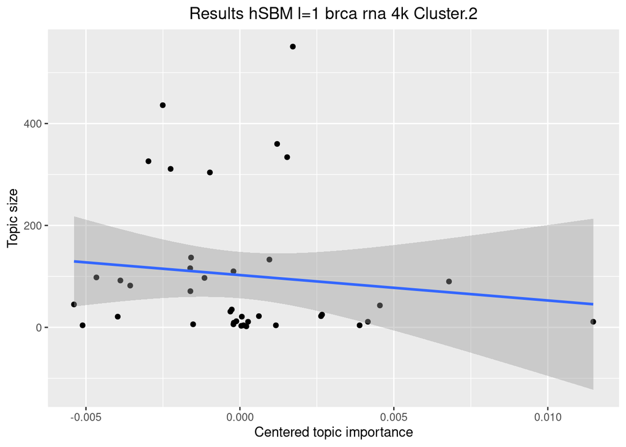

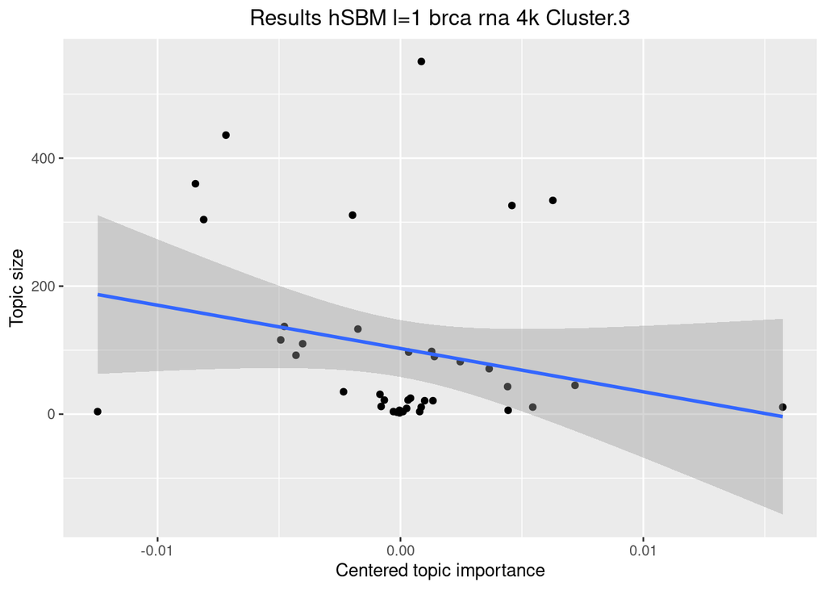

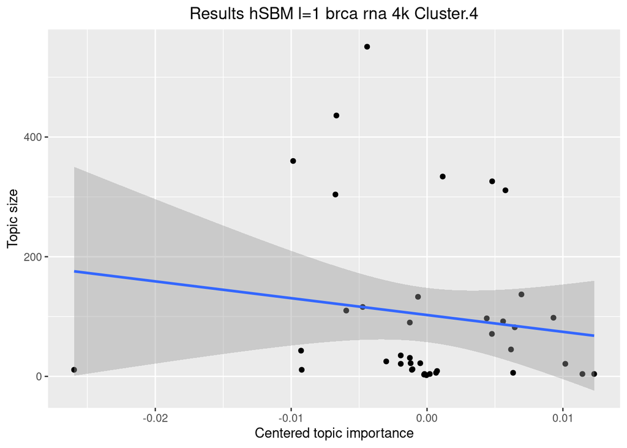

```r
cluster <- unique(stats_loi$info_centered$cluster)


for (cl in cluster) {
  p <- ggplot(stats_loi$info_centered[stats_loi$info_centered$cluster==cl,], aes(x=value, y=topic_length)) +
    geom_point() +
    labs(x="Centered topic importance", y="Topic size", title = paste("Results",loi_name, cl)) +
    geom_smooth(method='lm', formula= y~x) +
    theme(plot.title = element_text(hjust = 0.5))
  print(p)
}
```

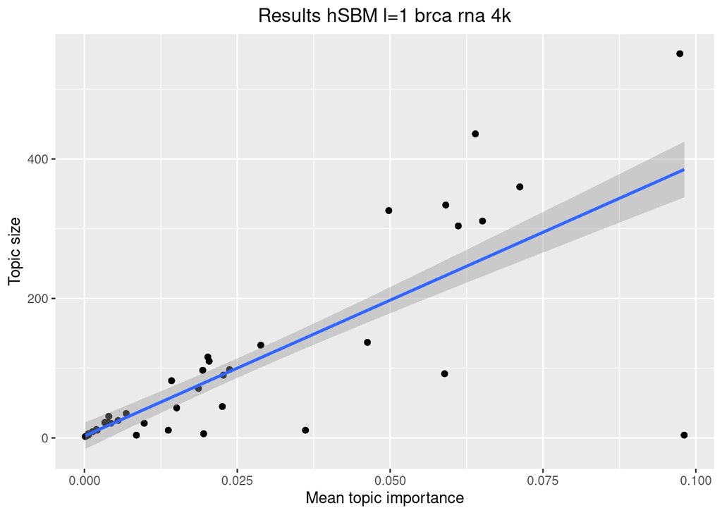

```r
p <- ggplot(stats_loi$info_centered, aes(x=topic_mean_imp, y=topic_length)) +
    geom_point() +
    labs(x="Mean topic importance", y="Topic size", title = paste("Results", loi_name)) +
    geom_smooth(method='lm', formula= y~x) +
    theme(plot.title = element_text(hjust = 0.5))
print(p)
```

Correlation value can also be simply calculated without visualization.

```r
topic_length_corr(stats_loi)
```

```
## [1] "centered_imp_Cluster.1"
## [1] 0.4396514
## [1] "centered_imp_Cluster.2"
## [1] -0.05466293
## [1] "centered_imp_Cluster.3"
## [1] 0.2341057
## [1] "centered_imp_Cluster.4"
## [1] 0.05780773
```

## Multi-omics nSBM

### Medium size data, all 3 layers (4k RNA, 2k Prot, 8k Phos)

Load multi-omics results, but specify the number of omics. The output has the same structure but with additional matrices for topics, topicdist and worddist for every omics layer. The clustering is the integratd result with only one clustering using all omics layers.

```r
#brca_medium_l0 <- read_sbm_output(folder_path = "data/sbm_output_brca_cptac/brca_nsbm_tests_medium",
#                                 level = 0,
#                                 omics_layers = 3)

brca_medium_l1 <- read_sbm_output(folder_path = "data/sbm_output_brca_cptac/brca_nsbm_tests_medium",
                                 level = 1,
                                 omics_layers = 3)

brca_medium_l2 <- read_sbm_output(folder_path = "data/sbm_output_brca_cptac/brca_nsbm_tests_medium",
                                 level = 2,
                                 omics_layers = 3)
```

```r
t(as.data.frame(brca_medium_l1$summary))
```

```
##                                 [,1]
## n_clust                      3.00000
## n_topics_rna                24.00000
## max_topic_length_rna       868.00000
## average_topic_length_rna   166.66667
## n_topics_prot               34.00000
## max_topic_length_prot      375.00000
## average_topic_length_prot   58.82353
## n_topics_phos               37.00000
## max_topic_length_phos     1200.00000
## average_topic_length_phos  217.56757
## n_samples                  119.00000
```

```r
t(as.data.frame(brca_medium_l2$summary))
```

```
##                               [,1]
## n_clust                      1.000
## n_topics_rna                 2.000
## max_topic_length_rna      3847.000
## average_topic_length_rna  2000.000
## n_topics_prot                2.000
## max_topic_length_prot     1924.000
## average_topic_length_prot 1000.000
## n_topics_phos                3.000
## max_topic_length_phos     7489.000
## average_topic_length_phos 2683.333
## n_samples                  119.000
```

```r
#sankey plot l1 & l2

brca_samp <- as.list(brca_cluster$Sample.ID)

#using level 1 & 2 in this case
l1 <- unlist(lapply(brca_samp, function(samp) {which(brca_medium_l1$clust == samp, arr.ind = TRUE)[2]}))
l2 <- unlist(lapply(brca_samp, function(samp) {which(brca_medium_l2$clust == samp, arr.ind = TRUE)[2]}))


#add the prviously published annotation "NMF.Cluster"
df <- data.frame("level_2" = l2, "level_1" = l1, "brca_subgroup" = brca_cluster$NMF.Cluster, row.names = brca_cluster$Sample.ID)
df_s <- get_sankey_input(df)
p <- sankeyNetwork(Links = df_s$links, Nodes = df_s$nodes,
                     Source = "IDsource", Target = "IDtarget",
                     Value = "value", NodeID = "name",
                     sinksRight=FALSE)
```

```
## Links is a tbl_df. Converting to a plain data frame.
```

```r
p
```

[interactive chart not shown]

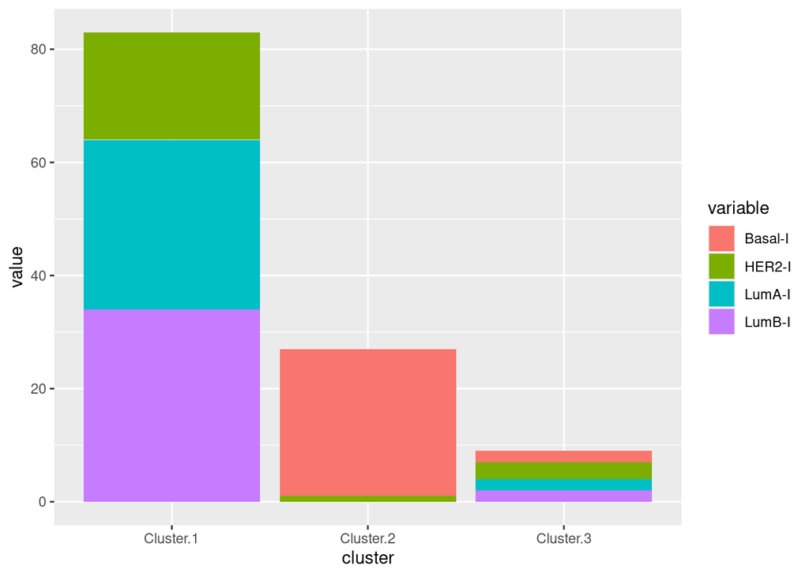

```r
#barplot level 1

df <- get_nsbmclust_df(brca_medium_l1$clust, anno = brca_cluster, anno_samplecol = 1, anno_groupcol = 8)

df$cluster <- rownames(df)
df <- melt(df, id = "cluster")

ggplot(df, aes(fill=variable, y=value, x=cluster)) +
    geom_bar(position="stack", stat="identity")
```

### Medium size data without phosph0 (4k RNA, 2k Prot)

```r
#brca_medium_noPhos_l0 <- read_sbm_output(folder_path = "data/sbm_output_brca_cptac/brca_nsbm_tests_medium_noPhos",
#                                 level = 0,
#                                 omics_layers = 2)

brca_medium_noPhos_l1 <- read_sbm_output(folder_path = "data/sbm_output_brca_cptac/brca_nsbm_tests_medium_noPhos",
                                 level = 1,
                                 omics_layers = 2)

brca_medium_noPhos_l2 <- read_sbm_output(folder_path = "data/sbm_output_brca_cptac/brca_nsbm_tests_medium_noPhos",
                                 level = 2,
                                 omics_layers = 2)
```

```r
t(as.data.frame(brca_medium_noPhos_l1$summary))
```

```
##                                [,1]
## n_clust                     3.00000
## n_topics_rna               41.00000
## max_topic_length_rna      591.00000
## average_topic_length_rna   97.56098
## n_topics_prot              36.00000
## max_topic_length_prot     405.00000
## average_topic_length_prot  55.55556
## n_samples                 119.00000
```

```r
t(as.data.frame(brca_medium_noPhos_l2$summary))
```

```
##                                [,1]
## n_clust                      1.0000
## n_topics_rna                 2.0000
## max_topic_length_rna      3869.0000
## average_topic_length_rna  2000.0000
## n_topics_prot                3.0000
## max_topic_length_prot     1874.0000
## average_topic_length_prot  666.6667
## n_samples                  119.0000
```

```r
#sankey plot l1 & l2

brca_samp <- as.list(brca_cluster$Sample.ID)

#using level 1 & 2 in this case
l1 <- unlist(lapply(brca_samp, function(samp) {which(brca_medium_noPhos_l1$clust == samp, arr.ind = TRUE)[2]}))
l2 <- unlist(lapply(brca_samp, function(samp) {which(brca_medium_noPhos_l2$clust == samp, arr.ind = TRUE)[2]}))


#add the prviously published annotation "NMF.Cluster"
df <- data.frame("level_2" = l2, "level_1" = l1, "brca_subgroup" = brca_cluster$NMF.Cluster, row.names = brca_cluster$Sample.ID)
df_s <- get_sankey_input(df)
p <- sankeyNetwork(Links = df_s$links, Nodes = df_s$nodes,
                     Source = "IDsource", Target = "IDtarget",
                     Value = "value", NodeID = "name",
                     sinksRight=FALSE)
```

```
## Links is a tbl_df. Converting to a plain data frame.
```

```r
p
```

[interactive chart not shown]

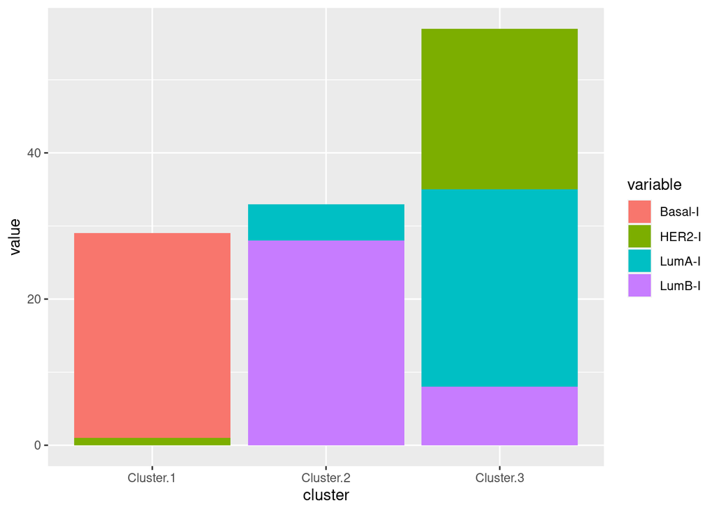

```r
#barplot level 1

df <- get_nsbmclust_df(brca_medium_noPhos_l1$clust, anno = brca_cluster, anno_samplecol = 1, anno_groupcol = 8)

df$cluster <- rownames(df)
df <- melt(df, id = "cluster")

ggplot(df, aes(fill=variable, y=value, x=cluster)) +
    geom_bar(position="stack", stat="identity")
```

### Further analysis for any multi-omics integration analysis level of interest

```r
#define omics type and matching level of interest
loi <- brca_medium_noPhos_l1
number_omics <- 2

loi_name <- "nSBM l=1 brca medium no phospho"
```

Calculate the rand index:

```r
df <- get_nsbmclust_df(loi$clust, anno = brca_cluster, anno_samplecol = 1, anno_groupcol = 8)
rand_index_sbmcluster(df)
```

```
## [1] 0.781
```

Take a closer look at topics by using the analyse_topics function which calculates different normalisations for topic scores, specifiying the number of omics layers.

```r
stats_loi <- analyse_topics(loi, omics_layers = number_omics)
```

Check the centered topic values aka “importance” for each each topic using the SBM assigned clustering. Since they are different topics for each omics layer, they are different topics for each layer. Centered topic values per cluster are calculated according to this publication: https://www.mdpi.com/2072-6694/16/7/1350.

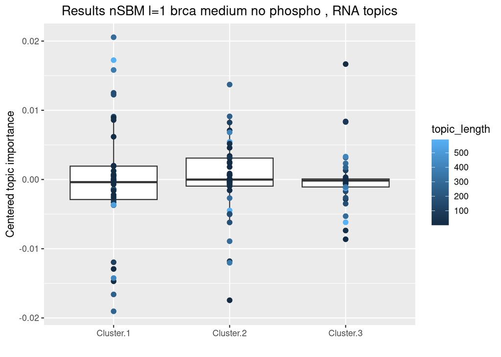

```r
ggplot(stats_loi$rna$info_centered, aes(x=cluster, y=value))+
  geom_boxplot() +
  geom_point(aes(group = factor(cluster), color=topic_length), show.legend = T, size = 2) +
  labs(x="", y="Centered topic importance", title = paste("Results", loi_name, ", RNA topics")) +
  theme(plot.title = element_text(hjust = 0.5))
```

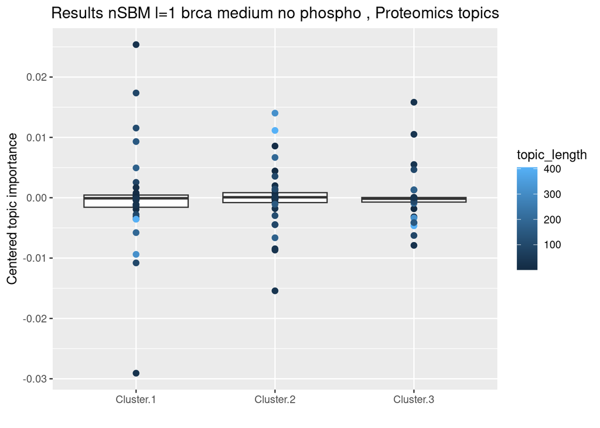

```r
ggplot(stats_loi$prot$info_centered, aes(x=cluster, y=value))+
  geom_boxplot() +
  geom_point(aes(group = factor(cluster), color=topic_length), show.legend = T, size = 2) +
  labs(x="", y="Centered topic importance", title = paste("Results", loi_name, ", Proteomics topics")) +
  theme(plot.title = element_text(hjust = 0.5))
```

```r
if (number_omics == 3) {
  ggplot(stats_loi$phos$info_centered, aes(x=cluster, y=value))+
  geom_boxplot() +
  geom_point(aes(group = factor(cluster), color=topic_length), show.legend = T, size = 2) +
  labs(x="", y="Centered topic importance", title = paste("Results", loi_name, ", Phospho topics")) +
  theme(plot.title = element_text(hjust = 0.5))
}
```

Check correlation between centered topic importance and topic length, vs correlation when only mean topic importance without centering.

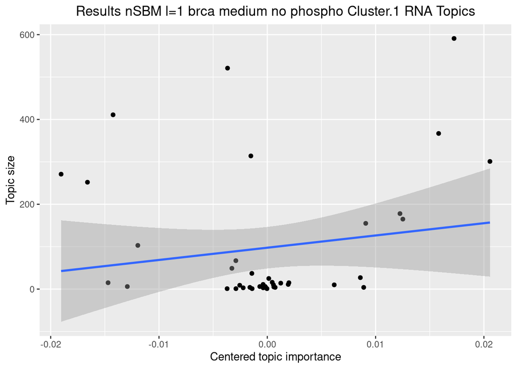

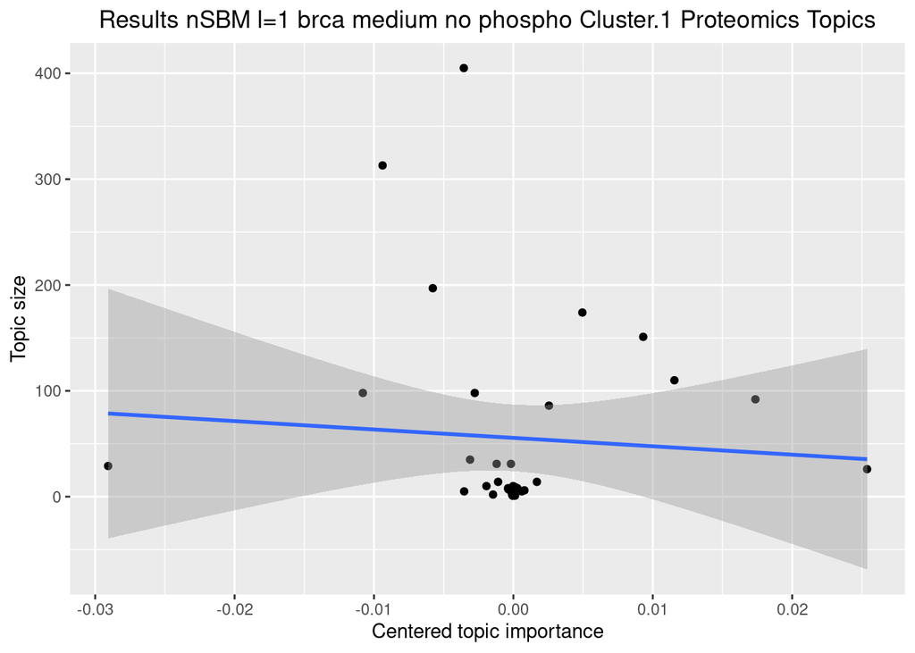

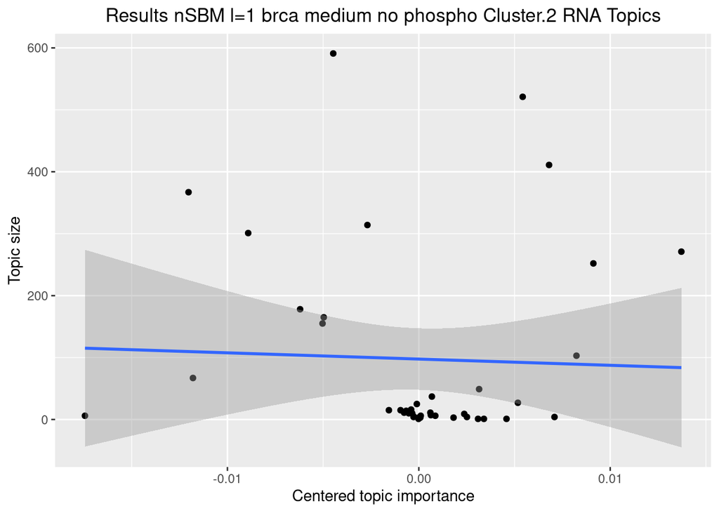

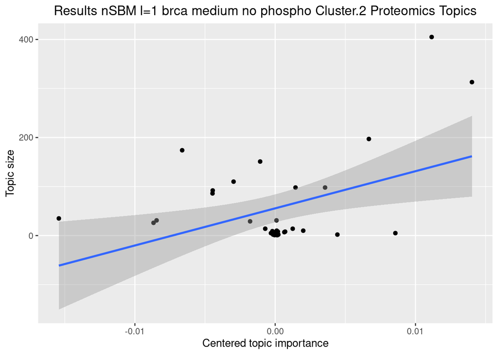

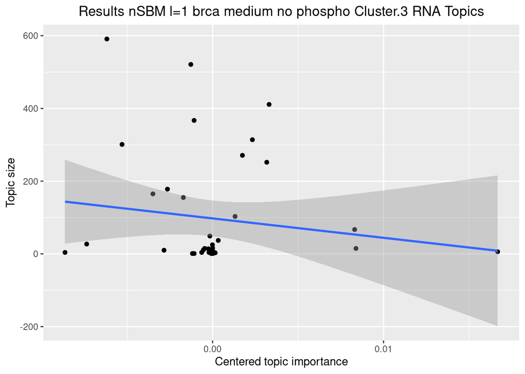

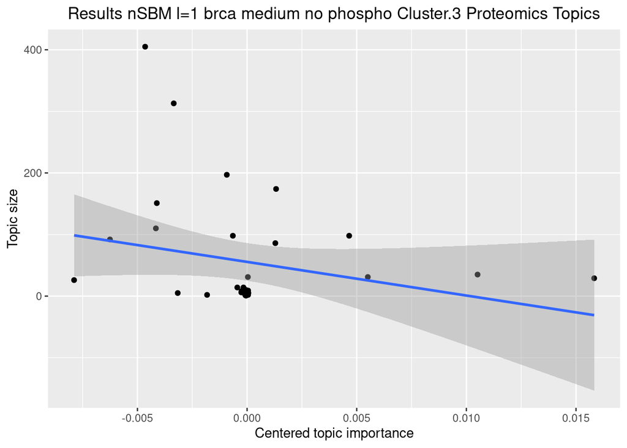

```r
cluster <- unique(stats_loi$rna$info_centered$cluster)


for (cl in cluster) {
  p <- ggplot(stats_loi$rna$info_centered[stats_loi$rna$info_centered$cluster==cl,], aes(x=value, y=topic_length)) +
    geom_point() +
    labs(x="Centered topic importance", y="Topic size", title = paste("Results",loi_name, cl, "RNA Topics")) +
    geom_smooth(method='lm', formula= y~x) +
    theme(plot.title = element_text(hjust = 0.5))
    print(p)

  l <- ggplot(stats_loi$prot$info_centered[stats_loi$prot$info_centered$cluster==cl,], aes(x=value, y=topic_length)) +
    geom_point() +
    labs(x="Centered topic importance", y="Topic size", title = paste("Results",loi_name, cl, "Proteomics Topics")) +
    geom_smooth(method='lm', formula= y~x) +
    theme(plot.title = element_text(hjust = 0.5))
  print(l)


  if (number_omics == 3) {
   o <- ggplot(stats_loi$phos$info_centered[stats_loi$phos$info_centered$cluster==cl,], aes(x=value, y=topic_length)) +
    geom_point() +
    labs(x="Centered topic importance", y="Topic size", title = paste("Results",loi_name, cl, "Phospho Topics")) +
    geom_smooth(method='lm', formula= y~x) +
    theme(plot.title = element_text(hjust = 0.5))
  }
}
```

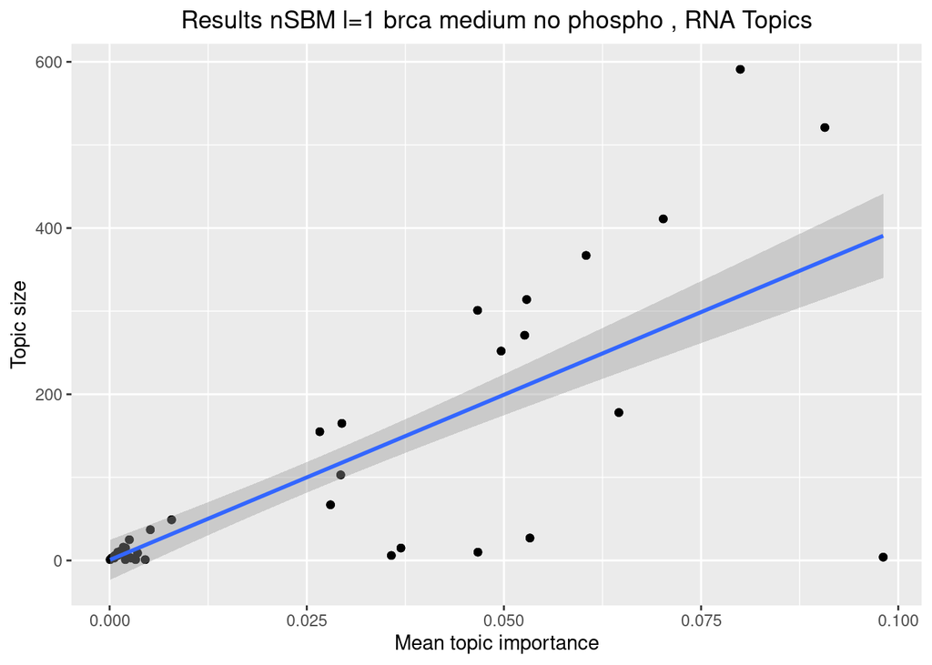

```r
ggplot(stats_loi$rna$info_centered, aes(x=topic_mean_imp, y=topic_length)) +
    geom_point() +
    labs(x="Mean topic importance", y="Topic size", title = paste("Results", loi_name, ", RNA Topics")) +
    geom_smooth(method='lm', formula= y~x) +
    theme(plot.title = element_text(hjust = 0.5))
```

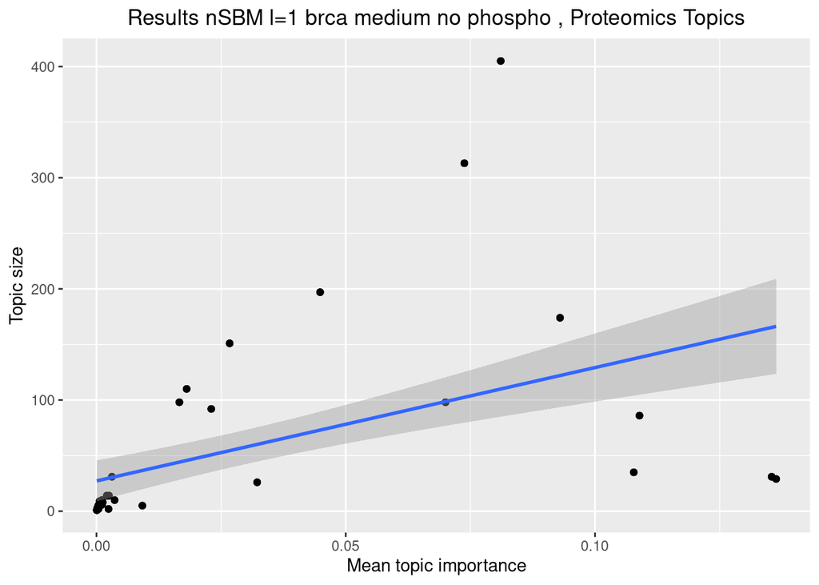

```r
ggplot(stats_loi$prot$info_centered, aes(x=topic_mean_imp, y=topic_length)) +
    geom_point() +
    labs(x="Mean topic importance", y="Topic size", title = paste("Results", loi_name, ", Proteomics Topics")) +
    geom_smooth(method='lm', formula= y~x) +
    theme(plot.title = element_text(hjust = 0.5))
```

```r
if (number_omics == 3) {
  ggplot(stats_loi$phos$info_centered, aes(x=topic_mean_imp, y=topic_length)) +
    geom_point() +
    labs(x="Mean topic importance", y="Topic size", title = paste("Results", loi_name, ", Phospho Topics")) +
    geom_smooth(method='lm', formula= y~x) +
    theme(plot.title = element_text(hjust = 0.5))
}
```

Correlation value can also be simply calculated without visualization.

```r
topic_length_corr(stats_loi$rna)
```

```
## [1] "centered_imp_Cluster.1"
## [1] 0.6221735
## [1] "centered_imp_Cluster.2"
## [1] 0.4380484
## [1] "centered_imp_Cluster.3"
## [1] 0.1519292
```

```r
topic_length_corr(stats_loi$prot)
```

```
## [1] "centered_imp_Cluster.1"
## [1] 0.2493077
## [1] "centered_imp_Cluster.2"
## [1] 0.6042177
## [1] "centered_imp_Cluster.3"
## [1] 0.2225333
```

```r
# topic_length_corr(stats_loi$phos)
```

## Identify topics of interest

This is a a simple way to identify topics of interest as specified in this publication: https://www.mdpi.com/2072-6694/16/7/1350.

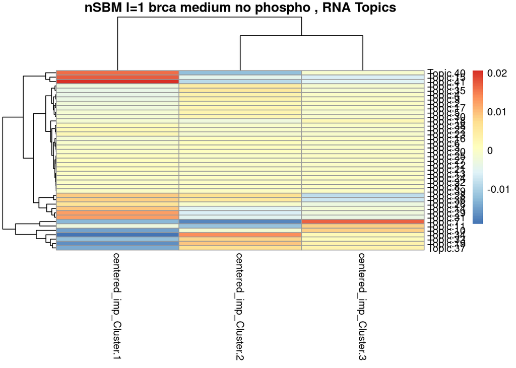

```r
#for rna
stats <- stats_loi$rna$info_all[,10:12]
pheatmap(stats, main = paste(loi_name, ", RNA Topics"))
```

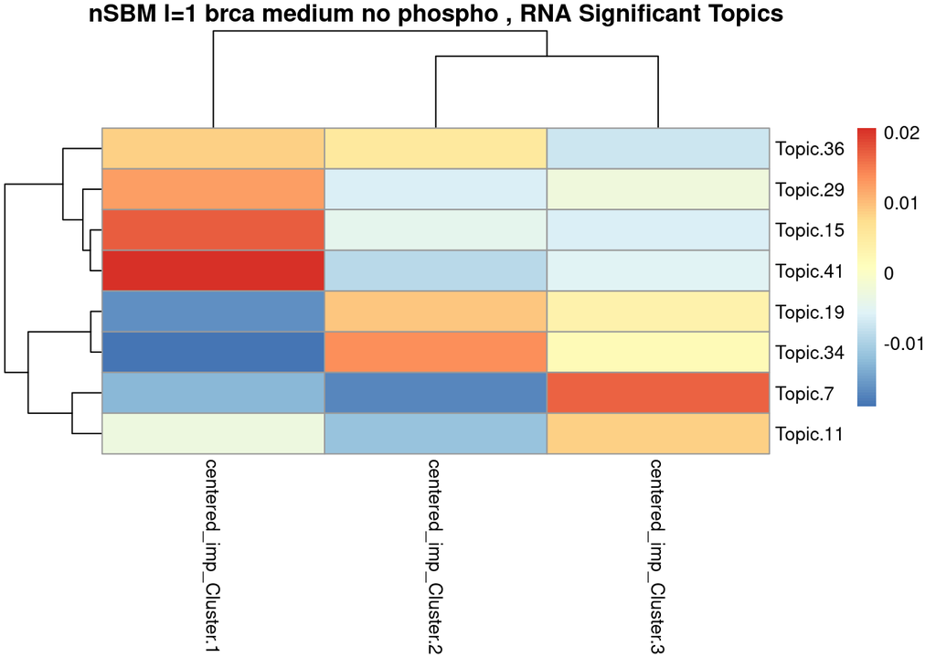

```r
m <- apply(stats, 2, mean)
std <- apply(stats, 2, function(x){sqrt(var(x))})
cl <- stats > m+2*std
cl_rna <- rownames(cl)[rowSums(cl) != 0]

pheatmap(stats[cl_rna,], main =  paste(loi_name, ", RNA Significant Topics"))
```

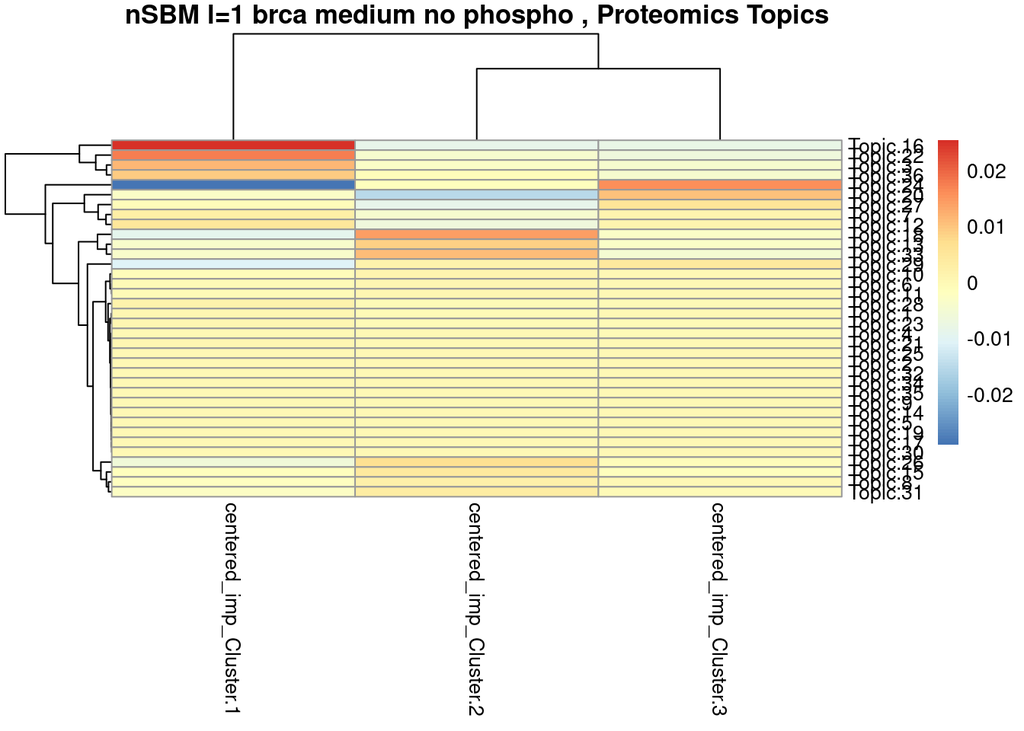

```r
#for proteomics
stats <- stats_loi$prot$info_all[,10:12]
pheatmap(stats, main = paste(loi_name, ", Proteomics Topics"))
```

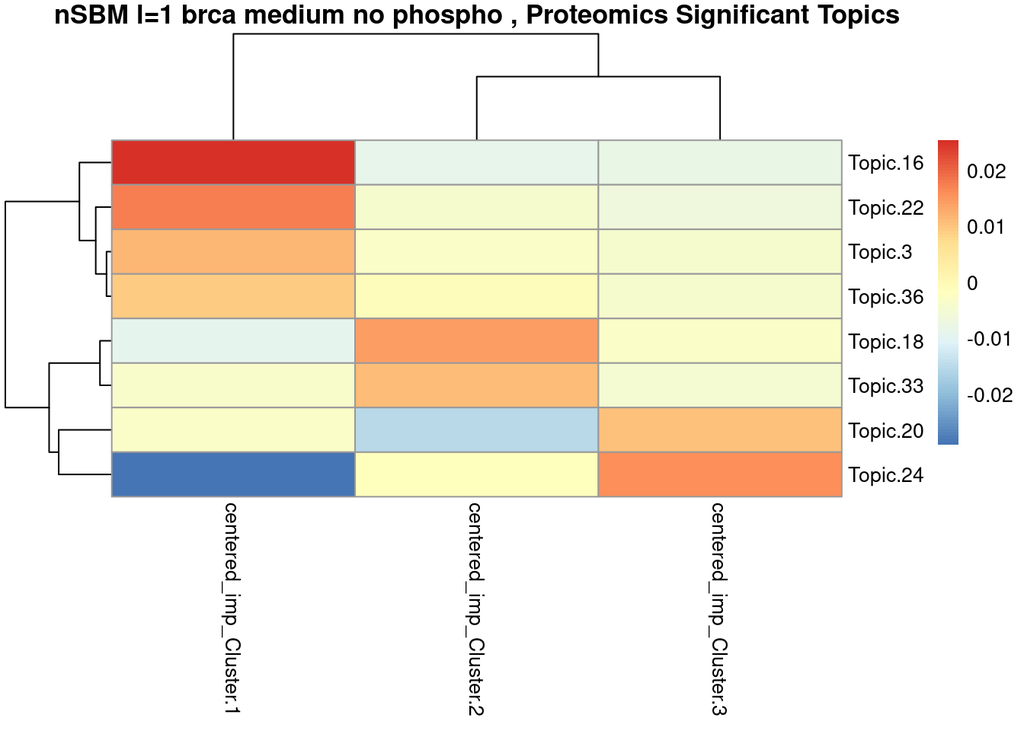

```r
m <- apply(stats, 2, mean)
std <- apply(stats, 2, function(x){sqrt(var(x))})
cl <- stats > m+2*std
cl_prot <- rownames(cl)[rowSums(cl) != 0]

pheatmap(stats[cl_prot,], main =  paste(loi_name, ", Proteomics Significant Topics") )
```

Topics for each cluster can also be identified manually, depending on the results and number of overall Topics/ Clusters.

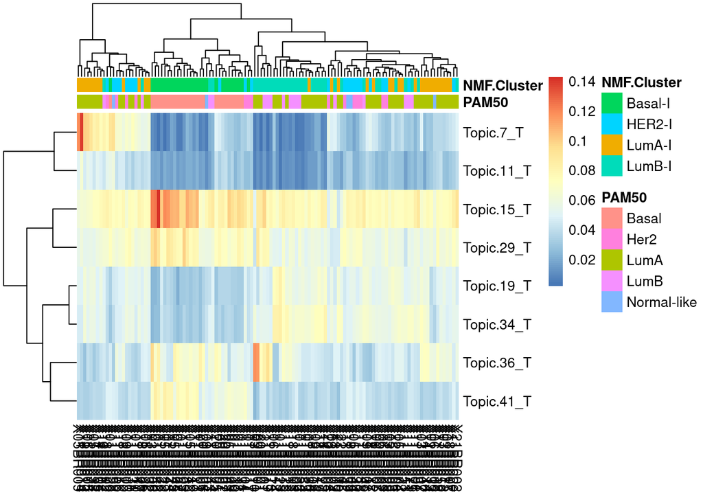

```r
todist_cut_rna <- brca_medium_noPhos_l1$todist_rna[,cl_rna]
colnames(todist_cut_rna) <- paste0(colnames(todist_cut_rna), "_T") #adding T for transcriptomics and P for proteomics to distinguisch the different topics
pheatmap(t(todist_cut_rna), annotation = brca_cluster[,c(7,8)])
```

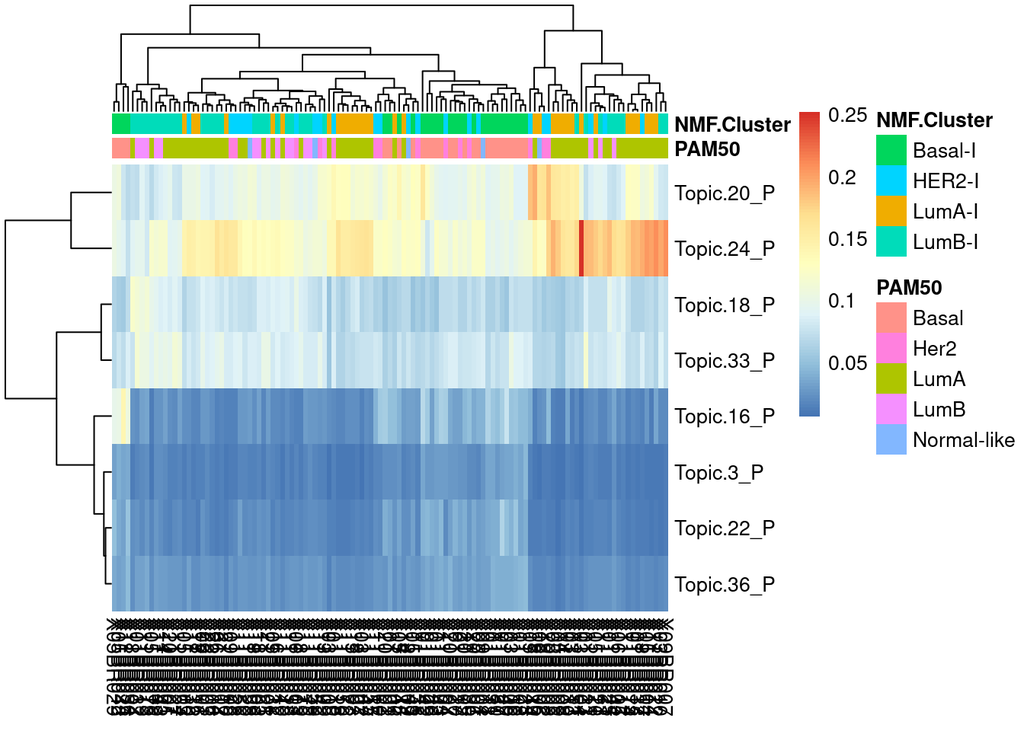

```r
todist_cut_prot <- brca_medium_noPhos_l1$todist_prot[,cl_prot]
colnames(todist_cut_prot) <- paste0(colnames(todist_cut_prot), "_P")
pheatmap(t(todist_cut_prot), annotation = brca_cluster[,c(7,8)])
```

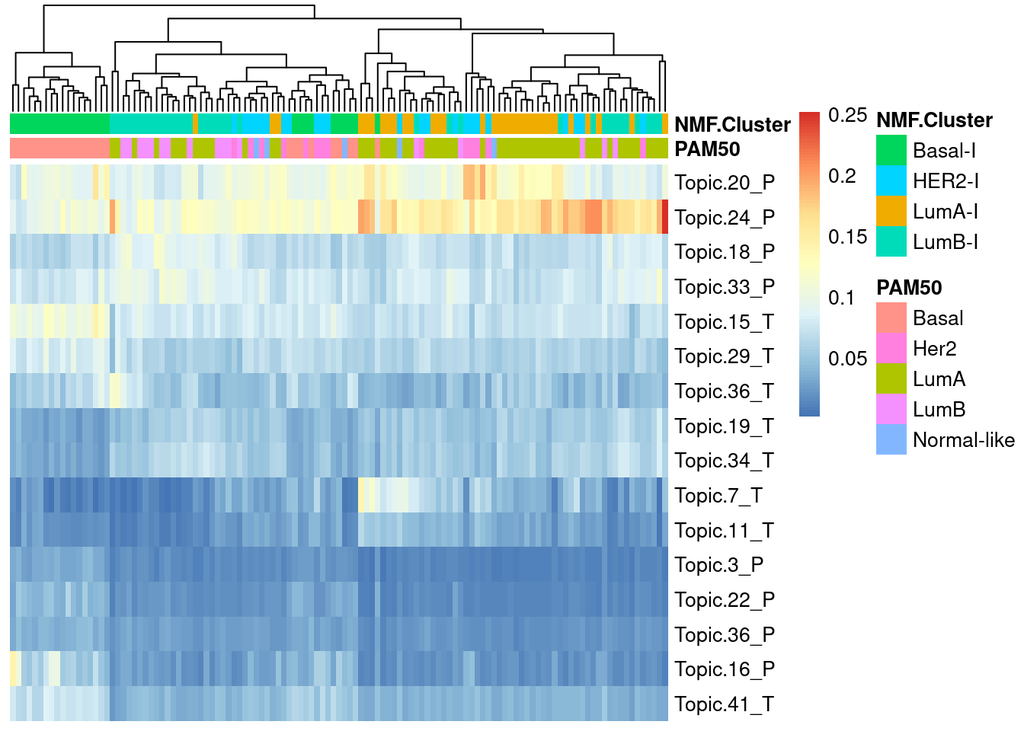

```r
todist_c <- cbind(todist_cut_prot, todist_cut_rna)
colnames(todist_c) <- paste0(str_remove(colnames(todist_c), "_.*$"), str_extract(colnames(todist_c), "_."))

pheatmap(t(todist_c), annotation = brca_cluster[,c(7,8)], treeheight_row = 0, show_colnames = FALSE)
```